# How different color shirts or days could change the way students dress.

## Dark Shirt Color Popularity

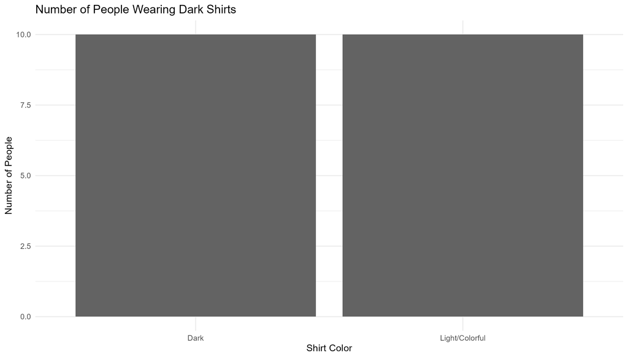

Dark Shirt Color Popularity

## Formal Shoe Wears by Day

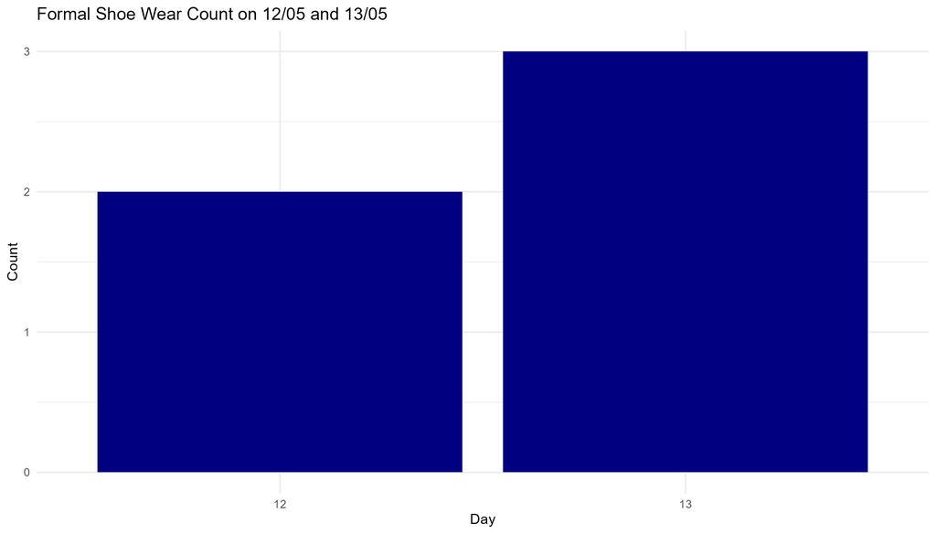

Formal Shoe Wears on 12/05 and 13/05

## Accessories and Shirt Color

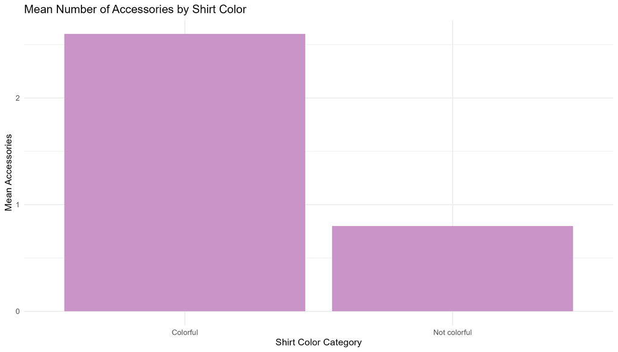

Number Of Accessories and Shirt Color

What I am investigating are style choices on shirt color, shoes and Accessories. Specifically patterns in shirt Color, Shoes, and Accessories, and what we could learn about someone based on their shirt color or more. We could also learn about peoples style choices based on the day, or time of the day.

For plot 3 I noticed those wearing more colorful clothing tended to wear more accessories on average than people who wear less colorful clothing (shades of black or white). This data can be used to convey the fact that people who wear colorful clothing probably care more about what they wear so they would have more accessories on average.